# Estado escolhido: Bahia (BH)

## Item a

A tábua de vida fornece estimativas da expectativa de vida às idades exatas até os 80 anos. Ela é utilizada para calcular as probabilidades de vida e morte de uma população, em função da idade. As faixas etárias a serem utilizadas são: 0 a 4 anos, 5 a 9 anos, 10 a 14 anos, 15 a 19 anos, 20 a 29 anos, 30 a 39 anos, 40 a 49 anos, 50 a 59 anos, 60 a 69 anos, 70 a 79 anos, 80 anos e mais. As colunas das tabelas serão:

- n: amplitude do intervalo do grupo etário;
- nDx: número de indivíduos mortos;
- nNx: número de indivíduos vivos na população;
- nMx: taxa específica de mortalidade;
- nax: taxa de pessoas que viveram certo tempo e morreram antes de completar a última idade do intervalo;
- nqx: probabilidade de morte;
- npx: probabilidade de sobrevivência;
- lx: coorte hipotética;
- ndx: número de indivíduos mortos na coorte;
- nLx: número de indivíduos vivos na coorte;
- nmx: taxa específica de mortalidade na coorte;
- Tx: Total de anos vividos pelo grupo etário a partir da idade;
- ex: esperança de vida.

Tábuas de vida para os sexos e os anos:

Tábua de vida para indivíduos do sexo masculino no Estado da Bahia, 1980.

|  | n | nDx | nNx | nMx | nax | nqx | npx | lx | ndx | nLx | nmx | Tx | ex |
| --- | --- | --- | --- | --- | --- | --- | --- | --- | --- | --- | --- | --- | --- |
| 0 | 5 | 9111 | 775565 | 0,0 | 1,6 | 0,1 | 0,9 | 100000,0 | 5648,2 | 480796,2 | 0,0 | 7146538,7 | 71,5 |
| 5 | 5 | 444 | 684987 | 0,0 | 2,5 | 0,0 | 1,0 | 94351,8 | 305,3 | 470995,8 | 0,0 | 6665742,5 | 70,6 |
| 10 | 5 | 338 | 628735 | 0,0 | 2,5 | 0,0 | 1,0 | 94046,5 | 252,5 | 469601,5 | 0,0 | 6194746,7 | 65,9 |
| 15 | 5 | 480 | 523837 | 0,0 | 2,5 | 0,0 | 1,0 | 93794,1 | 428,7 | 467898,5 | 0,0 | 5725145,2 | 61,0 |
| 20 | 10 | 1259 | 699511 | 0,0 | 2,5 | 0,0 | 1,0 | 93365,3 | 1658,0 | 921218,0 | 0,0 | 5257246,7 | 56,3 |
| 30 | 10 | 1379 | 471857 | 0,0 | 2,5 | 0,0 | 1,0 | 91707,3 | 2622,7 | 897403,0 | 0,0 | 4336028,7 | 47,3 |
| 40 | 10 | 1696 | 352152 | 0,0 | 2,5 | 0,0 | 1,0 | 89084,6 | 4140,8 | 859790,1 | 0,0 | 3438625,7 | 38,6 |
| 50 | 10 | 2215 | 247954 | 0,0 | 2,5 | 0,1 | 0,9 | 84943,8 | 7111,7 | 796100,6 | 0,0 | 2578835,6 | 30,4 |
| 60 | 10 | 2615 | 170156 | 0,0 | 2,5 | 0,1 | 0,9 | 77832,1 | 10725,2 | 697882,2 | 0,0 | 1782735,0 | 22,9 |
| 70 | 10 | 3191 | 86393 | 0,0 | 2,5 | 0,3 | 0,7 | 67106,9 | 19409,7 | 525496,6 | 0,0 | 1084852,7 | 16,2 |
| 80+ | 10 | 1734 | 20335 | 0,1 | 11,7 | 1,0 | 0,0 | 47697,2 | 47697,2 | 559356,1 | 0,1 | 559356,1 | 11,7 |

Tábua de vida para indivíduos do sexo feminino no Estado da Bahia, 1980.

|  | n | nDx | nNx | nMx | nax | nqx | npx | lx | ndx | nLx | nmx | Tx | ex |
| --- | --- | --- | --- | --- | --- | --- | --- | --- | --- | --- | --- | --- | --- |
| 0 | 5 | 7686 | 763358 | 0,0 | 1,6 | 0,0 | 1,0 | 100000,0 | 4867,7 | 483449,8 | 0,0 | 7640322,1 | 76,4 |
| 5 | 5 | 290 | 669494 | 0,0 | 2,5 | 0,0 | 1,0 | 95132,3 | 205,8 | 475147,0 | 0,0 | 7156872,3 | 75,2 |
| 10 | 5 | 245 | 627055 | 0,0 | 2,5 | 0,0 | 1,0 | 94926,5 | 185,3 | 474169,3 | 0,0 | 6681725,3 | 70,4 |
| 15 | 5 | 319 | 542760 | 0,0 | 2,5 | 0,0 | 1,0 | 94741,2 | 278,0 | 473011,1 | 0,0 | 6207556,0 | 65,5 |
| 20 | 10 | 728 | 749924 | 0,0 | 2,5 | 0,0 | 1,0 | 94463,2 | 910,4 | 937804,3 | 0,0 | 5734544,9 | 60,7 |
| 30 | 10 | 938 | 504401 | 0,0 | 2,5 | 0,0 | 1,0 | 93552,8 | 1715,8 | 922659,7 | 0,0 | 4796740,7 | 51,3 |
| 40 | 10 | 1168 | 372746 | 0,0 | 2,5 | 0,0 | 1,0 | 91837,0 | 2811,6 | 897282,9 | 0,0 | 3874080,9 | 42,2 |
| 50 | 10 | 1421 | 250690 | 0,0 | 2,5 | 0,1 | 0,9 | 89025,4 | 4840,5 | 853950,1 | 0,0 | 2976798,0 | 33,4 |
| 60 | 10 | 1910 | 175489 | 0,0 | 2,5 | 0,1 | 0,9 | 84184,9 | 8471,1 | 778315,7 | 0,0 | 2122847,9 | 25,2 |
| 70 | 10 | 2784 | 93960 | 0,0 | 2,5 | 0,2 | 0,8 | 75713,8 | 18354,9 | 619476,6 | 0,0 | 1344532,1 | 17,8 |
| 80+ | 10 | 2321 | 29339 | 0,1 | 12,6 | 1,0 | 0,0 | 57358,9 | 57358,9 | 725055,6 | 0,1 | 725055,6 | 12,6 |

(Para a Bahia no ano de 2010, havia valores faltantes para a faixa etária “mais de 80 anos”, então o ultimo grupo de idade colocado na tabela foi de 70 a 79 anos)

Tábua de vida para indivíduos do sexo masculino no Estado da Bahia, 2010.

|  | n | nDx | nNx | nMx | nax | nqx | npx | lx | ndx | nLx | nmx | Tx | ex |
| --- | --- | --- | --- | --- | --- | --- | --- | --- | --- | --- | --- | --- | --- |
| 0 | 5 | 2405 | 539406 | 0 | 1,6 | 0,0 | 1,0 | 100000,0 | 2196,0 | 492533,6 | 0 | 7908237 | 79,1 |
| 5 | 5 | 230 | 606662 | 0 | 2,5 | 0,0 | 1,0 | 97804,0 | 185,2 | 488556,9 | 0 | 7415704 | 75,8 |
| 10 | 5 | 358 | 681776 | 0 | 2,5 | 0,0 | 1,0 | 97618,8 | 256,0 | 487453,9 | 0 | 6927147 | 71,0 |
| 15 | 5 | 1588 | 667977 | 0 | 2,5 | 0,0 | 1,0 | 97362,8 | 1150,5 | 483937,8 | 0 | 6439693 | 66,1 |
| 20 | 10 | 4254 | 1289284 | 0 | 2,5 | 0,0 | 1,0 | 96212,3 | 3097,9 | 938889,2 | 0 | 5955755 | 61,9 |
| 30 | 10 | 3697 | 1051499 | 0 | 2,5 | 0,0 | 1,0 | 93114,5 | 3189,7 | 907221,5 | 0 | 5016866 | 53,9 |
| 40 | 10 | 4124 | 817773 | 0 | 2,5 | 0,0 | 1,0 | 89924,7 | 4369,6 | 866475,2 | 0 | 4109645 | 45,7 |
| 50 | 10 | 5358 | 569832 | 0 | 2,5 | 0,1 | 0,9 | 85555,1 | 7514,6 | 799191,6 | 0 | 3243169 | 37,9 |
| 60 | 10 | 6284 | 363859 | 0 | 2,5 | 0,2 | 0,8 | 78040,5 | 11932,4 | 690912,4 | 0 | 2443978 | 31,3 |
| 70 | 10 | 7386 | 195863 | 0 | 26,5 | 1,0 | 0,0 | 66108,2 | 66108,2 | 1753065,4 | 0 | 1753065 | 26,5 |

(Para a Bahia no ano de 2010, havia valores faltantes para a faixa etária “mais de 80 anos”, então o ultimo grupo de idade colocado na tabela foi de 70 a 79 anos):

Tábua de vida para indivíduos do sexo feminino no Estado da Bahia, 2010.

|  | n | nDx | nNx | nMx | nax | nqx | npx | lx | ndx | nLx | nmx | Tx | ex |
| --- | --- | --- | --- | --- | --- | --- | --- | --- | --- | --- | --- | --- | --- |
| 0 | 5 | 1966 | 522234 | 0 | 1,6 | 0,0 | 1,0 | 100000,0 | 1858,5 | 493681,1 | 0 | 9739549 | 97,4 |
| 5 | 5 | 138 | 584494 | 0 | 2,5 | 0,0 | 1,0 | 98141,5 | 115,8 | 490418,0 | 0 | 9245868 | 94,2 |
| 10 | 5 | 197 | 657784 | 0 | 2,5 | 0,0 | 1,0 | 98025,7 | 146,7 | 489761,8 | 0 | 8755450 | 89,3 |
| 15 | 5 | 329 | 658343 | 0 | 2,5 | 0,0 | 1,0 | 97879,0 | 244,3 | 488784,5 | 0 | 8265688 | 84,4 |
| 20 | 10 | 911 | 1323626 | 0 | 2,5 | 0,0 | 1,0 | 97634,8 | 668,5 | 971333,6 | 0 | 7776903 | 79,7 |
| 30 | 10 | 1359 | 1102489 | 0 | 2,5 | 0,0 | 1,0 | 96966,2 | 1184,3 | 960779,9 | 0 | 6805570 | 70,2 |
| 40 | 10 | 2169 | 866809 | 0 | 2,5 | 0,0 | 1,0 | 95781,9 | 2352,6 | 940174,7 | 0 | 5844790 | 61,0 |
| 50 | 10 | 3319 | 626909 | 0 | 2,5 | 0,1 | 0,9 | 93429,3 | 4757,5 | 898612,3 | 0 | 4904615 | 52,5 |
| 60 | 10 | 4503 | 413455 | 0 | 2,5 | 0,1 | 0,9 | 88671,9 | 8928,1 | 819757,9 | 0 | 4006003 | 45,2 |
| 70 | 10 | 6165 | 246329 | 0 | 40,0 | 1,0 | 0,0 | 79743,8 | 79743,8 | 3186245,1 | 0 | 3186245 | 40,0 |

Gráficos comparando ambos os sexos em 1980 e em 2010: (A cor azul representa homem e vermelho representa mulher.)

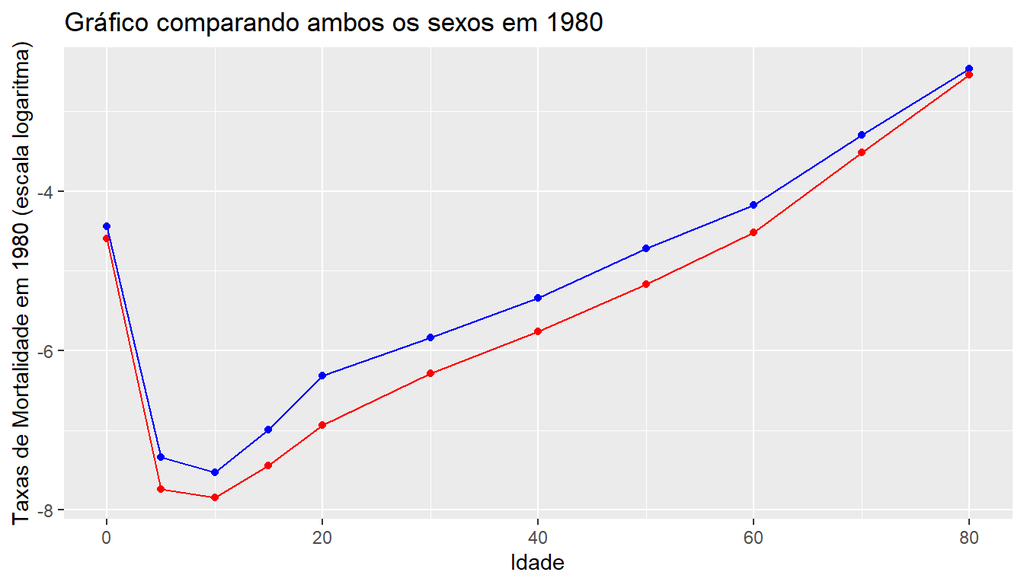

[figure not shown]

Com as 4 tabelas e os 2 gráficos, conclui-se que em ambos os anos, as taxas de mortalidade dos homens são maiores do que as das mulheres. Uma razão para esse fenômeno é que os homens, em geral, fazem diagnóstico tardio de doenças graves, não seguem o tratamento recomendado, estão mais expostos aos acidentes de trabalho e trânsito, utilizam álcool e drogas em maior quantidade, envolvem-se mais em situações de violência do que as mulheres e não praticam atividade física com regularidade como as mulheres. Outro motivo é que a saúde pública prioriza a saúde da criança e da mulher. Além disso, nota-se que as esperanças de vida de ambos os sexos, para todas as faixas etárias aumentaram de 1980 para 2010. Um motivo disso foram os avanços no campo da medicina que permitiram que a sociedade pudesse ter acesso a vacinas, medicamentos e maiores cuidados com a saúde. Outros motivos foram a melhoria do saneamento básico e a diminuição da miséria.